# How to perform differential correlation analysis using DGCA

Andrew McKenzie, Bin Zhang

November 2, 2016

# 1 Introduction

DGCA (Differential Gene Correlation Analysis) is an R package to calculate, sort, visualize, and make sense of differential correlation patterns. Over the past several decades, a wealth of high-dimensional biological data types have emerged to allow the analysis of gene expression at a systems level, including microarray, RNA-seq, proteomics, epigenomics, metabolomics, lipidomics, and many others. An extremely common use of these data types is to gather and compare samples from multiple conditions, e.g., disease and non-diseased, in an attempt to identify molecular identifiers (e.g., probes, transcripts, genomic features, proteins, metabolites, lipids; henceforth, “genes”) that distinguish between the conditions. Currently, the most common method of comparing samples from different conditions is through statistical tests to identify genes that have higher relative levels in one condition than another, which is commonly known as differential expression analysis. However, methods have also emerged for gaining insights into the difference in the relationships between genes between conditions, which, in the case of expression data, is commonly known as differential co-expression or differential correlation analysis.

In this vignette we introduce DGCA, an R package to identify differential correlation between gene pairs in multiple conditions. DGCA shares some features with existing implementations for identifying differential correlation. For example, like DiffCorr, DGCA transforms sample correlation coefficients to z-scores and uses differences in z-scores to calculate p-values of differential correlation between gene pairs. And like Discordant, DGCA allows users the ability to classify differentially correlated gene pairs between two conditions into the nine possible categories. However, DGCA differs from existing differential correlation implementations in three key ways. First, DGCA allows users to generate permutation samples from their data, and thus offers users a non-parametric option for testing the significance of the differential correlation relationships they identify. Second, by harnessing these permutation samples, DGCA also allow users to test whether the average difference in correlation between one gene and a set of other genes is significantly different between two conditions. Third, DGCA offers users downstream options designed to help turn the differential correlation structure in their data into knowledge, including visualization and gene ontology (GO) enrichment analysis. This vignette shows the demonstrates the practical use of DGCA on single cell RNA-seq data comparing gene expression in neurons to oligodendrocytes, from Darmanis *et al.* (Darmanis 2015).

# 2 Quick Analysis

First, we will load the package and read in some example data from single-cell RNA-sequencing data from neurons and oligodendrocytes, generated in Darmanis *et al.* (Darmanis 2015), cleaned for this analysis, and put in the data folder.

```r
library(DGCA, quietly = TRUE)
data(darmanis)
data(design_mat)
```

Note that the design matrix is a standard design matrix as used in other packages (e.g., limma, DESEq, MatrixEQTL), and specifies the group indices to be extracted from the original columns.

To run the full differential correlation analysis and extract all of the top differentially correlated pairs, run this:

```r
ddcor_res = ddcorAll(inputMat = darmanis, design = design_mat,
  compare = c("oligodendrocyte", "neuron"),
  adjust = "none", heatmapPlot = FALSE, nPerm = 0, nPairs = 100)
head(ddcor_res)
```

```
##    Gene1  Gene2 oligodendrocyte_cor oligodendrocyte_pVal neuron_cor
## 1 CACYBP   NACA        -0.070261455           0.67509118  0.9567267
## 2 CACYBP    SSB        -0.055290516           0.74162636  0.9578999
## 3 NDUFB9    SSB        -0.009668455           0.95405875  0.9491904
## 4 CACYBP NDUFB9         0.333616044           0.04066732  0.9709674
## 5 CACYBP   ST13        -0.104422773           0.53268567  0.9246014
## 6   NACA    NCL        -0.168001214           0.31334753  0.9051576
##   neuron_pVal zScoreDiff     pValDiff Classes
## 1           0  10.256977 1.100991e-24     0/+
## 2           0  10.251847 1.161031e-24     0/+
## 3           0   9.515191 1.813802e-21     0/+
## 4           0   9.145779 5.920161e-20     +/+
## 5           0   8.951700 3.500493e-19     0/+
## 6           0   8.666293 4.464170e-18     0/+
```

To run the full differential correlation analysis to find the top differentially correlated pairs for one specific gene compared to all of the others, specify one gene for the “splitSet” argument. Here, we specify the gene “RTN4”:

```r
ddcor_res = ddcorAll(inputMat = darmanis, design = design_mat,
  compare = c("oligodendrocyte", "neuron"),
  adjust = "none", heatmapPlot = FALSE, nPerm = 0, splitSet = "RTN4")
head(ddcor_res)
```

```
##    Gene1 Gene2 oligodendrocyte_cor oligodendrocyte_pVal neuron_cor
## 1 COX6A1  RTN4         -0.14366658            0.3895065  0.8513757
## 2   NACA  RTN4         -0.11316838            0.4987289  0.8543674
## 3 NDUFB9  RTN4          0.03053324            0.8556029  0.8623108
## 4    UBB  RTN4          0.04794437            0.7750003  0.8528796
## 5 CACYBP  RTN4          0.07272359            0.6643624  0.8577493
## 6    SSB  RTN4          0.06587898            0.6943441  0.8528114
##   neuron_pVal zScoreDiff     pValDiff Classes
## 1           0   7.296730 2.948461e-13     0/+
## 2           0   7.192726 6.351033e-13     0/+
## 3           0   6.600928 4.085911e-11     0/+
## 4           0   6.325298 2.527438e-10     0/+
## 5           0   6.290375 3.166991e-10     0/+
## 6           0   6.230608 4.646295e-10     0/+
```

The rest of this vignette will perform this full pipeline step-by-step and help you understand some of the different options available in DGCA.

# 3 Step-by-step analysis

## 3.1 Setting up the inputs to DGCA

```r
str(darmanis, list.len = 5)
```

```
## 'data.frame':    572 obs. of  158 variables:
##  $ GSM1657871: num  0.00 6.85e-05 1.71e-04 1.60e-05 1.37e-06 ...
##  $ GSM1657873: num  0.00 2.20e-05 1.66e-04 2.18e-04 2.34e-06 ...
##  $ GSM1657876: num  7.77e-07 3.61e-05 5.56e-05 7.77e-06 6.60e-06 ...
##  $ GSM1657877: num  3.58e-05 2.01e-04 2.27e-04 3.60e-04 0.00 ...
##  $ GSM1657881: num  2.81e-06 6.73e-06 2.83e-04 4.58e-04 0.00 ...
##   [list output truncated]
```

```r
head(rownames(darmanis))
```

```
## [1] "AASDHPPT" "ACSL3"    "ACTB"     "ACTG1"    "ADD1"     "ADD3"
```

Our goal will be to identify differences in the correlations between two genes in the two different cell types (neurons and oligodendrocytes).

The design matrix is created based on data from a separate file that maps sample names to cell types. Using a vector of names corresponding to each of the columns in the overall matrix, we can create such a design matrix:

```r
n_oligo_samples = 38; n_neuron_samples = 120
cell_type = c(rep("oligodendrocyte", n_oligo_samples), rep("neuron", n_neuron_samples))
design_mat = model.matrix(~ cell_type + 0)
colnames(design_mat) = c("neuron", "oligodendrocyte")
str(design_mat)
```

```
##  num [1:158, 1:2] 0 0 0 0 0 0 0 0 0 0 ...
##  - attr(*, "dimnames")=List of 2
##   ..$ : chr [1:158] "1" "2" "3" "4" ...
##   ..$ : chr [1:2] "neuron" "oligodendrocyte"
##  - attr(*, "assign")= int [1:2] 1 1
##  - attr(*, "contrasts")=List of 1
##   ..$ cell_type: chr "contr.treatment"
```

```r
design_mat = makeDesign(cell_type)
```

## 3.2 Filtering the input genes

It is often the case that the genes with the lowest average expression levels, or the lowest variance in expression levels, are less likely to have interesting and/or biologically relevant differences in correlation between conditions. Therefore, it is sometimes desirable to filter the input expression matrix to remove these genes, both so that there are fewer spurious differential correlations in the resulting table, and so that the p-value adjustment for multiple comparisons (if any) will not be affected by these genes with a lower pre-test probability of differential correlation.

In order to filter the input data in this way, DGCA offers a convenient function called filterGenes. Although the Darmanis et al. RNA data has already been filtered to only include genes with expression levels in >= the 95th percentile in each of oligodendrocytes and neurons, we will show how to filter this data for the purposes of demonstration.

The first way that the input data can be filtered is by removing genes with a low average – or more precisely, a low measure of central tendency. The default central tendency measure is the median, and the default percentile is the 30th percentile, although these can both be adjusted.

Notably, most of the filtering methods (except for rowMeans) require the matrixStats library, so we load it here prior to filtering the genes.

```r
library(matrixStats, quietly = TRUE)
nrow(darmanis)
```

```
## [1] 572
```

```r
darmanis_mean_filtered = filterGenes(darmanis,
  filterTypes = "central", filterCentralType = "median", filterCentralPercentile = 0.3)
nrow(darmanis_mean_filtered)
```

```
## [1] 400
```

The second way that the input data can be filtered is by removing genes that have a low value in a dispersion measure. The default dispersion measure is the coefficient of variation, or CV, since this normalizes the dispersion of each gene to the mean and therefore makes the dispersion measure a more independent of the central tendency measure.

```r
nrow(darmanis)
```

```
## [1] 572
```

```r
darmanis_cv_filtered = filterGenes(darmanis,
  filterTypes = "dispersion", filterDispersionType = "cv",
  filterDispersionPercentile = 0.3)
nrow(darmanis_cv_filtered)
```

```
## [1] 400
```

It is also possible to do both mean and variance filtering in series, by setting filterType to c(“central”, “dispersion”), and by setting sequential = TRUE (which is the default). Otherwise, if sequential = FALSE, the same genes removed by the central tendency filtering could potentially be removed by the dispersion filtering.

In general, some amount of central tendency and dispersion filtering is recommended for high-dimensional data sets, because low central tendency and/or low dispersion genes are unlikely to have interesting differential correlation, and this also allows the package operations to run substantially faster.

Note that this function can certainly be used even if the data will not be eventually loaded into DGCA – it is present in the package merely for the convenience of our users.

## 3.3 Finding the correlations and the significance of the correlations in each condition

When you input data to DGCA, the first thing that DGCA will do is to subset the input data into matrices based on the design matrix, +/- the splitSet of row identifiers.

The second thing that DGCA does is to find the correlation values in each condition, the number of non-NA samples used in each correlation calculation, and the significance of that correlation value. This behavior can be demonstrated via the use of the getCors function.

Since we know that the first 38 columns of our input data are from oligodendrocytes, then we can calculate the correlations for that condition only by first subsetting the data frame.

The major input to getCors are the same as the inputs for DGCA – the input matrix and the design matrix.

```r
cor_res = getCors(inputMat = darmanis, design = design_mat)
str(cor_res)
```

```
## Formal class 'corMats' [package "DGCA"] with 3 slots
##   ..@ corMatList:List of 2
##   .. ..$ neuron         :List of 3
##   .. .. ..$ corrs : num [1:572, 1:572] 1 0.0456 0.3592 0.2483 0.2102 ...
##   .. .. .. ..- attr(*, "dimnames")=List of 2
##   .. .. .. .. ..$ : chr [1:572] "AASDHPPT" "ACSL3" "ACTB" "ACTG1" ...
##   .. .. .. .. ..$ : chr [1:572] "AASDHPPT" "ACSL3" "ACTB" "ACTG1" ...
##   .. .. ..$ pvals : num [1:572, 1:572] NA NA NA NA NA NA NA NA NA NA ...
##   .. .. ..$ nsamps: int [1:572, 1:572] 120 120 120 120 120 120 120 120 120 120 ...
##   .. ..$ oligodendrocyte:List of 3
##   .. .. ..$ corrs : num [1:572, 1:572] 1 -0.0387 -0.0645 0.5138 -0.055 ...
##   .. .. .. ..- attr(*, "dimnames")=List of 2
##   .. .. .. .. ..$ : chr [1:572] "AASDHPPT" "ACSL3" "ACTB" "ACTG1" ...
##   .. .. .. .. ..$ : chr [1:572] "AASDHPPT" "ACSL3" "ACTB" "ACTG1" ...
##   .. .. ..$ pvals : num [1:572, 1:572] NA NA NA NA NA NA NA NA NA NA ...
##   .. .. ..$ nsamps: int [1:572, 1:572] 38 38 38 38 38 38 38 38 38 38 ...
##   ..@ design    : num [1:158, 1:2] 0 0 0 0 0 0 0 0 0 0 ...
##   .. ..- attr(*, "dimnames")=List of 2
##   .. .. ..$ : chr [1:158] "1" "2" "3" "4" ...
##   .. .. ..$ : chr [1:2] "neuron" "oligodendrocyte"
##   .. ..- attr(*, "assign")= int [1:2] 1 1
##   .. ..- attr(*, "contrasts")=List of 1
##   .. .. ..$ cell_type: chr "contr.treatment"
##   ..@ options   : Named chr "pearson"
##   .. ..- attr(*, "names")= chr "corrType"
```

Note that the correlation method can be changed from Pearson correlation to Spearman correlation (i.e., rank-based correlation) via switching the corrType parameter from corrType = “pearson”, the default, to corrType = “spearman”.

Note also that the lowest p-value reportable using this method is 2.2e-16. Below this, the p-values of the correlation significance test will be reported as 0.

Finally, note that this result can have more than two conditions, based on the number of columns in the design matrix. It is only when you calculate the pairwise differential correlation between conditions as below that you must choose to compare two conditions.

## 3.4 Finding the differential correlations between conditions

Once you have the information necessary for each correlation matrix, this can be inputted into the function pairwiseDCor in order to calculate differential correlations between conditions.

```r
dcPairs_res = pairwiseDCor(cor_res, compare = c("oligodendrocyte", "neuron"))
str(dcPairs_res)
```

```
## Formal class 'dcPair' [package "DGCA"] with 7 slots
##   ..@ corA    : num [1:572, 1:572] 1 -0.0387 -0.0645 0.5138 -0.055 ...
##   .. ..- attr(*, "dimnames")=List of 2
##   .. .. ..$ : chr [1:572] "AASDHPPT" "ACSL3" "ACTB" "ACTG1" ...
##   .. .. ..$ : chr [1:572] "AASDHPPT" "ACSL3" "ACTB" "ACTG1" ...
##   ..@ corPvalA: num [1:572, 1:572] NA NA NA NA NA NA NA NA NA NA ...
##   ..@ corB    : num [1:572, 1:572] 1 0.0456 0.3592 0.2483 0.2102 ...
##   .. ..- attr(*, "dimnames")=List of 2
##   .. .. ..$ : chr [1:572] "AASDHPPT" "ACSL3" "ACTB" "ACTG1" ...
##   .. .. ..$ : chr [1:572] "AASDHPPT" "ACSL3" "ACTB" "ACTG1" ...
##   ..@ corPvalB: num [1:572, 1:572] NA NA NA NA NA NA NA NA NA NA ...
##   ..@ ZDiff   : num [1:572, 1:572] NA NA NA NA NA NA NA NA NA NA ...
##   .. ..- attr(*, "dimnames")=List of 2
##   .. .. ..$ : chr [1:572] "AASDHPPT" "ACSL3" "ACTB" "ACTG1" ...
##   .. .. ..$ : chr [1:572] "AASDHPPT" "ACSL3" "ACTB" "ACTG1" ...
##   ..@ PValDiff: num [1:572, 1:572] NA NA NA NA NA NA NA NA NA NA ...
##   ..@ options : logi(0)
```

Note that this function returns a dcPair class object, which contains the correlations from each condition, the statistical significance of those correlations, and well as the difference of the z-transformed correlation values between the two conditions, and the p-value of the z-score difference.

## 3.5 Extracting the top differentially correlated pairs from the dcPairs object

In order to extract the top differentially correlated pairs from the dcPairs object, you can use accessor functions. One accessor function is dcTopPairs. The only required argument aside from the dcPairs object is the number of correlation pairs to have in the resulting table. By default, the correlation values will be classified into groups, although this can be changed by setting classify = FALSE.

```r
dd_pairs = dcTopPairs(dcPairs_res, nPairs = 100, classify = TRUE)
head(dd_pairs)
```

```
##    Gene1  Gene2         corA  corA_pVal      corB corB_pVal zScoreDiff
## 1 CACYBP   NACA -0.070261455 0.67509118 0.9567267         0  10.256977
## 2 CACYBP    SSB -0.055290516 0.74162636 0.9578999         0  10.251847
## 3 NDUFB9    SSB -0.009668455 0.95405875 0.9491904         0   9.515191
## 4 CACYBP NDUFB9  0.333616044 0.04066732 0.9709674         0   9.145779
## 5 CACYBP   ST13 -0.104422773 0.53268567 0.9246014         0   8.951700
## 6   NACA    NCL -0.168001214 0.31334753 0.9051576         0   8.666293
##       pValDiff Classes
## 1 1.100991e-24     0/+
## 2 1.161031e-24     0/+
## 3 1.813802e-21     0/+
## 4 5.920161e-20     +/+
## 5 3.500493e-19     0/+
## 6 4.464170e-18     0/+
```

## 3.6 Plotting the expression of gene pairs in multiple conditions

If you are interested in plotting the original expression values in multiple conditions (perhaps in order to visualize gene pairs with the top differential correlations between conditions), you can make use of ggplot2 to create scatterplots displaying this data.

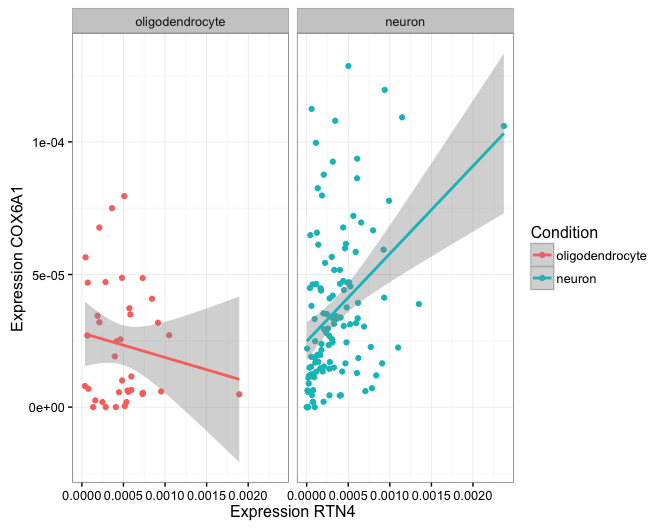

```r
library(ggplot2, quietly = TRUE)
#remove one outlier sample before visualization
darmanis = darmanis[ , -which.max(darmanis["COX6A1", ])]
design_mat = design_mat[-which.max(darmanis["COX6A1", ]), ]
plotCors(inputMat = darmanis, design = design_mat, compare = c("oligodendrocyte", "neuron"), geneA = "RTN4", geneB = "COX6A1")
```

## 3.7 Adjusting the resulting p-values without permutation testing

DGCA offers a variety of options for adjusting the resulting differential correlation p-values without permutation testing, including base R methods from p.adjust and methods from the external package fdrtool. These are accessed during the extraction process of the table from the dcPairs class object, since the p-value adjustment will be different in the case that all of the top differentially correlated pairs are selected, as opposed to the case that only the differentially correlated pairs with respect to one gene are selected. Here, we show one of the most common p-value adjustment methods by setting adjust = “BH”. Note that “BH” refers to Benjamini-Hochberg p-value adjustment.

```r
dd_pairs = dcTopPairs(dcPairs_res, nPairs = 100, classify = TRUE, adjust = "BH")
head(dd_pairs)
```

```
##    Gene1  Gene2         corA  corA_pVal      corB corB_pVal zScoreDiff
## 1 CACYBP   NACA -0.070261455 0.67509118 0.9567267         0  10.256977
## 2 CACYBP    SSB -0.055290516 0.74162636 0.9578999         0  10.251847
## 3 NDUFB9    SSB -0.009668455 0.95405875 0.9491904         0   9.515191
## 4 CACYBP NDUFB9  0.333616044 0.04066732 0.9709674         0   9.145779
## 5 CACYBP   ST13 -0.104422773 0.53268567 0.9246014         0   8.951700
## 6   NACA    NCL -0.168001214 0.31334753 0.9051576         0   8.666293
##       pValDiff pValDiff_adj Classes
## 1 1.100991e-24 5.805157e-23     0/+
## 2 1.161031e-24 5.805157e-23     0/+
## 3 1.813802e-21 6.046006e-20     0/+
## 4 5.920161e-20 1.480040e-18     +/+
## 5 3.500493e-19 7.000987e-18     0/+
## 6 4.464170e-18 7.440284e-17     0/+
```

fdrtool is a separate R package that also allows for p-value adjustment, e.g. via controlling the false non-discovery rate, “fndr”. To use these options, you need to load the package fdrtool. fdrtool also allows users to visualize the way in which the p-values were adjusted. This option is turned off by default but can be turned on using plotFdr = TRUE.

```r
library(fdrtool, quietly = TRUE)
dd_pairs_RTN4 = dcTopPairs(dcPairs_res, nPairs = 100, classify = TRUE, adjust = "fndr", plotFdr = FALSE)
head(dd_pairs_RTN4)
```

```
##    Gene1  Gene2         corA  corA_pVal      corB corB_pVal zScoreDiff
## 1 CACYBP   NACA -0.070261455 0.67509118 0.9567267         0  10.256977
## 2 CACYBP    SSB -0.055290516 0.74162636 0.9578999         0  10.251847
## 3 NDUFB9    SSB -0.009668455 0.95405875 0.9491904         0   9.515191
## 4 CACYBP NDUFB9  0.333616044 0.04066732 0.9709674         0   9.145779
## 5 CACYBP   ST13 -0.104422773 0.53268567 0.9246014         0   8.951700
## 6   NACA    NCL -0.168001214 0.31334753 0.9051576         0   8.666293
##       pValDiff pValDiff_adj Classes
## 1 1.100991e-24            0     0/+
## 2 1.161031e-24            0     0/+
## 3 1.813802e-21            0     0/+
## 4 5.920161e-20            0     +/+
## 5 3.500493e-19            0     0/+
## 6 4.464170e-18            0     0/+
```

Note that this is a toy example and that if you’re going to use fdrtool you should in general use larger input test statistics to generate more reliable FDR estimates.

## 3.8 Adjusting the resulting p-values with permutation testing

In order to perform permutation testing, it is necessary to specify this at the beginning of the analysis, since the permutation samples will need to go through each of the steps for correlation and differential correlation calculation as well. Therefore, the way to perform permutation testing is to use the ddcorAll function. The p-values are converted to empirical p-values and then to q-values using methods adapted from the R package qvalue.

```r
data(darmanis)
data(design_mat)
ddcor_res_perm = ddcorAll(inputMat = darmanis, design = design_mat,
  compare = c("oligodendrocyte", "neuron"),
  adjust = "perm", heatmapPlot = FALSE, nPerm = 10, splitSet = "RTN4")
head(ddcor_res_perm)
```

```
##    Gene1 Gene2 oligodendrocyte_cor oligodendrocyte_pVal neuron_cor
## 1 COX6A1  RTN4         -0.14366658            0.3895065  0.8513757
## 2   NACA  RTN4         -0.11316838            0.4987289  0.8543674
## 3 NDUFB9  RTN4          0.03053324            0.8556029  0.8623108
## 4    UBB  RTN4          0.04794437            0.7750003  0.8528796
## 5 CACYBP  RTN4          0.07272359            0.6643624  0.8577493
## 6    SSB  RTN4          0.06587898            0.6943441  0.8528114
##   neuron_pVal zScoreDiff     pValDiff     empPVals pValDiff_adj Classes
## 1           0   7.296730 2.948461e-13 0.0001751313  0.007007604     0/+
## 2           0   7.192726 6.351033e-13 0.0001751313  0.007007604     0/+
## 3           0   6.600928 4.085911e-11 0.0001751313  0.007007604     0/+
## 4           0   6.325298 2.527438e-10 0.0001751313  0.007007604     0/+
## 5           0   6.290375 3.166991e-10 0.0001751313  0.007007604     0/+
## 6           0   6.230608 4.646295e-10 0.0001751313  0.007007604     0/+
```

You can set the number of permutations using the nPerm parameter. Note that you should also set adjust = “perm”, because otherwise a different p-value adjustment method will be used, and the time spent generating the permutation samples will have been wasted.

## 3.9 Spearman (rank-based) differential correlation analysis

Often times it is desirable to use a non-parametric measure for correlation because of the distribution of your input data. In this case, you can use rank-based correlation in DGCA by setting corrType = “spearman”. A downside to using this is that it is slower to calculate the correlation matrices.

```r
ddcor_res = ddcorAll(inputMat = darmanis, design = design_mat,
  compare = c("oligodendrocyte", "neuron"),
  adjust = "none", heatmapPlot = FALSE, nPerm = 0, corrType = "spearman", nPairs = 100)
head(ddcor_res)
```

```
##    Gene1    Gene2 oligodendrocyte_cor oligodendrocyte_pVal neuron_cor
## 1  CALM2      UBB          -0.3997155         1.290705e-02 0.64309774
## 2 PPP1CB     RPL5          -0.3106637         5.764887e-02 0.66060341
## 3 ATP5G2      CNP           0.8360263         6.449241e-11 0.09933391
## 4  CALM2     PSAP          -0.4752161         2.569606e-03 0.51998146
## 5  SEPT7     TPI1          -0.3286637         4.393652e-02 0.63524313
## 6  ALDOA RAP1GDS1          -0.3386585         3.754433e-02 0.62297360
##    neuron_pVal zScoreDiff     pValDiff Classes
## 1 2.220446e-15   5.982889 2.192140e-09     -/+
## 2 2.220446e-16   5.621998 1.887613e-08     0/+
## 3 2.803956e-01  -5.586712 2.314095e-08     +/0
## 4 1.154769e-09   5.510773 3.572618e-08     -/+
## 5 6.661338e-15   5.502637 3.741515e-08     -/+
## 6 3.019807e-14   5.456958 4.843598e-08     -/+
```

## 3.10 Log transforming the input data to DGCA

Because of the highly skewed nature of microarray and RNA-sequencing data, it is often a good idea to log-transform input data prior to performing gene expression analysis on that data. Notably, if you do this, you will likely want to add a small constant to the input data set, because if there are negative or zero values prior to the log transform, NaN’s will result that will cause a large proportion of the correlation values in one or both of the conditions to be NA, which will then propagate to the differential correlation difference in z-scores and corresponding p-value. Here is some example code to show you how to do this, using the natural logarithm of the data:

```r
darmanis_log = log(darmanis + 1)
ddcor_res_RTN4 = ddcorAll(inputMat = darmanis_log, design = design_mat,
  compare = c("oligodendrocyte", "neuron"),
  adjust = "none", heatmapPlot = FALSE, nPerm = 0, splitSet = "RTN4", nPairs = 525)
```

```
## Classifying the differential correlation calls.
```

```r
head(ddcor_res_RTN4)
```

```
##    Gene1 Gene2 oligodendrocyte_cor oligodendrocyte_pVal neuron_cor
## 1 COX6A1  RTN4         -0.14365302            0.3895517  0.8509396
## 2   NACA  RTN4         -0.11316192            0.4987536  0.8538801
## 3 NDUFB9  RTN4          0.03060531            0.8552656  0.8618100
## 4    UBB  RTN4          0.04799340            0.7747762  0.8525474
## 5 CACYBP  RTN4          0.07276865            0.6641666  0.8572379
## 6    SSB  RTN4          0.06593406            0.6941009  0.8523163
##   neuron_pVal zScoreDiff     pValDiff Classes
## 1           0   7.288443 3.135578e-13     0/+
## 2           0   7.183341 6.802837e-13     0/+
## 3           0   6.590434 4.385440e-11     0/+
## 4           0   6.318726 2.637292e-10     0/+
## 5           0   6.280112 3.383302e-10     0/+
## 6           0   6.220912 4.942733e-10     0/+
```

## 3.11 Imputing gene expression measurements

Ocassionally, users may have NAs in their data, and DGCA offers a way to replace them using the k-nearest neighbors method from the impute package. If you want to run this, you need to have the impute library installed.

```r
library(impute, quietly = TRUE)
darmanis_na = darmanis
darmanis_na["RTN4", 1] = NA #add an NA value to demonstrate
ddcor_res = ddcorAll(inputMat = darmanis_na, design = design_mat,
  compare = c("oligodendrocyte", "neuron"),
  adjust = "none", nPerm = 0, impute = TRUE)
```

Note that you can also run impute when identifying the differentially correlated genes with respect to a small group of genes, using the splitSet argument, as long as all of your columns have >80% of non-missing data for the full set of splitSet genes. Otherwise, the k-nearest neighbors algorithm will not work. If this is not the case for your data, you will need to find a different way around that missing data problem. For example, you could remove those columns prior to inputting them to DGCA.

## 3.12 Classifying differential correlations into groups

The classify = TRUE argument is optional. If chosen, what it does is to split all of your rows into 9 classes, based on their differential connectivity:

1. **+/+** – Positively correlation in both conditions A and B.
2. **+/0** – Positive correlation in condition A, and no significant correlation in condition B.
3. **+/-** – Positive correlation in condition A, and negative correlation in condition B.
4. **0/+** – No significant correlation in condition A, and positive correlation in condition B.
5. **0/0** – No significant correlation in either condition.
6. **0/-** – No significant correlation in condition A, and negative correlation in condition B.
7. **-/+** – Negative correlation in condition A, and positive correlation in condition B.
8. **-/0** – Negative correlation in condition A, and no significant correlation in condition B.
9. **-/-** – Negative correlation in both conditions A and B.

Genes will not be categorized into any of these categories unless they pass the overall significance threshold for differential correlation. The default value for this is 0.05, and it can be altered by setting the corSigThresh argument. Further, in order to change the value at which an individual correlation is called significant, you can alter the sigThresh argument, which by default is also 0.05.

## 3.13 Specifying the correlation ceiling

The Fisher Z-transformation of the correlation values allows for a variance-stabilizing transformation of the correlation values, whose variance usually decreases as they approach -1 or 1. However, when you are testing many differentially correlated gene pairs, the Z-transformation will cause abberantly high correlation values, such as those 0.99+, to dominate the differential correlation calculations, even in the case that those two identifiers are highly correlated in the other condition as well. Therefore, correlation values of ~0.99+ are usually due to noise in the case of experiments with relatively small sample sizes, it is recommended that users use a ceiling on the correlation scores to avoid this skewing of the results. By default this threshold is set to 0.99, and it can be changed by altering the corr_cutoff argument. Note that the corr_cutoff parameter will alter the Z-score difference and the p-values corresponding to that difference, but will not alter the actual correlation value or its significance in the results tables.

## 3.14 Gene-trait differential correlation analysis

Doing gene-trait differential correlation analysis is straightforward with DGCA, because you can combine the traits into the same matrix, and then treat the trait as the splitSet object which you use to calculate the correlations in both conditions. As an example of this, we read in the ages of the brain cell extracted from the cortex in the Darmanis et al. experiment, and find genes that have a significant change in correlation with age in oligodendrocytes as compared to neurons.

```r
data(ages_darmanis)
rownames_darmanis = rownames(darmanis)
darmanis_with_traits = rbind(ages_darmanis, darmanis)
rownames(darmanis_with_traits) = c("age", rownames_darmanis)
ddcor_res = ddcorAll(inputMat = darmanis_with_traits, design = design_mat,
  compare = c("oligodendrocyte", "neuron"),
  adjust = "none", nPerm = 0, splitSet = "age")
head(ddcor_res)
```

```
##    Gene1 Gene2 oligodendrocyte_cor oligodendrocyte_pVal neuron_cor
## 1 TMSB4X   age          -0.4290660          0.007188363  0.4037711
## 2    UBC   age          -0.3673120          0.023294120  0.4225843
## 3  VDAC3   age          -0.4983515          0.001451418  0.2669619
## 4 EIF4G2   age          -0.4878443          0.001890560  0.2388812
## 5  RPL19   age          -0.4453690          0.005078071  0.2788500
## 6 KIF21A   age          -0.3896211          0.015607361  0.2917770
##    neuron_pVal zScoreDiff     pValDiff Classes
## 1 4.806732e-06   4.603400 4.156483e-06     -/+
## 2 1.525041e-06   4.339977 1.424976e-05     -/+
## 3 3.203545e-03   4.259805 2.046055e-05     -/+
## 4 8.599518e-03   4.032019 5.529971e-05     -/+
## 5 2.041751e-03   3.972477 7.112918e-05     -/+
## 6 1.222998e-03   3.694879 2.199917e-04     -/+
```

# 4 Dissecting the differential correlation structure

## 4.1 Visualization via heatmap of correlations in each condition

In order to visualize the differential correlation structure, DGCA offers a heatmap function. To turn it on, set the heatmapPlot argument to TRUE within ddcorAll. This requires the function heatmap.2 from the library gplots. Note that you can specify additional plotting options to the heatmap.2 at the end of the ddcorAll function.

Since heatmaps are best visualized with a small number of genes, we first filter the genes down to a more manageable number by selecting the genes with the highest medians and coefficients of variation.

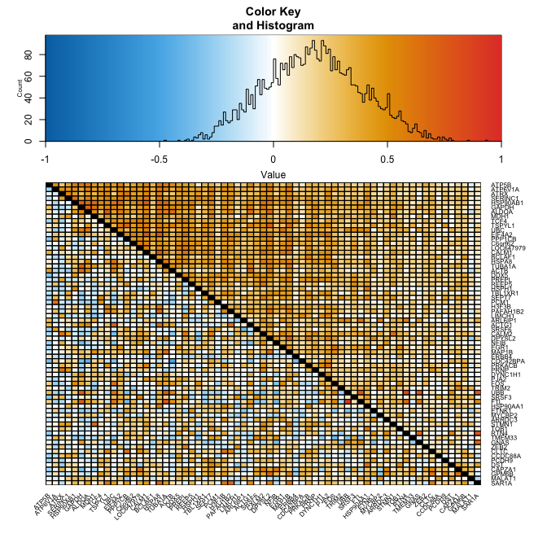

```r
library(gplots, quietly = TRUE)
darmanis_top =  filterGenes(darmanis,
  filterTypes = c("central", "dispersion"), filterCentralPercentile = 0.75,
  filterDispersionPercentile = 0.75)
ddcor_res = ddcorAll(inputMat = darmanis_top, design = design_mat,
  compare = c("oligodendrocyte", "neuron"),
  adjust = "none", heatmapPlot = TRUE, nPerm = 0, nPairs = "all")
```

As you can see, DGCA sorts the rows of the correlation matrices by the average z-score of correlation difference, so that you can visualize patterns of differences in correlation across the two conditions and help identify key genes that are more or less correlated with all of the other genes in one condition versus another. In this example, the gene *GPM6B* has relatively stronger correlation with the other genes in the set in oligodendrocytes than in neurons, while the gene *ARL6IP1* has relatively stronger correlation with the other genes in the set in neurons than in oligodendrocytes.

## 4.2 Calculating the average change in correlation for each gene with all others

```r
library(matrixStats)
ddcor_res = ddcorAll(inputMat = darmanis_top, design = design_mat,
  compare = c("oligodendrocyte", "neuron"),
  adjust = "perm", heatmapPlot = FALSE, nPerm = 20, nPairs = "all",
  getDCorAvg = TRUE, dCorAvgType = "gene_average", dCorAvgMethod = "median")
head(ddcor_res$avg_dcor)
```

```
##        Gene avgZDiff empirical_pVal pVal_adj
## 6     ATP5B 2.076289              0        0
## 7   ATP6V1A 2.001076              0        0
## 8      ATRX 1.948192              0        0
## 54  SERINC1 1.935309              0        0
## 32 HSP90AB1 1.822795              0        0
## 27    GAPDH 1.808580              0        0
```

## 4.3 Calculating the average change in correlation for all genes with all genes

```r
library(matrixStats)
ddcor_res = ddcorAll(inputMat = darmanis_top, design = design_mat,
  compare = c("oligodendrocyte", "neuron"),
  adjust = "perm", heatmapPlot = FALSE, nPerm = 20, nPairs = "all",
  getDCorAvg = TRUE, dCorAvgType = "total_average", dCorAvgMethod = "median")
head(ddcor_res$avg_dcor)
```

```
## $total_zdiff
## [1] 0.9617991
##
## $pVal
## [1] 0
```

# 5 Gene ontology enrichment analysis of differentially correlated gene classes using GOstats

Commonly, investigators are more interested in the overall pattern of genes with changes in correlation between conditions, rather than the differential correlation of individual gene pairs. In this case, DGCA offers a convenience function for extracting gene lists corresponding to the differential correlation classes, converting the resulting gene symbols to inputs for gene ontology enrichment testing, and integrating with the GOstats R package to return the gene ontology enrichment testing results. If you want to use this convenience function, you need to have the GOstats library installed. So far, this convenience function is only tested for use with a single gene splitSet analysis.

In order to run this function, we need to load the necessary libraries. Of course, since we are using Since this experiment has human gene symbols, we use the annotation library org.Hs.eg.db. We also choose clean them to make sure that that they are the most updated gene symbol versions, where possible, for which we need the HGNChelper R package. If you do not want to clean your HGNC gene symbols prior to converting to Ensembl gene symbols, set HGNC_clean = FALSE. If you already have Ensembl symbols and do not need to convert from HGNC symbols to Ensembl, set HGNC_switch = FALSE. By default, these two options are set to TRUE, since in our experience, HGNC symbols are more commonly encountered than Ensembl symbols.

```r
library(GOstats, quietly = TRUE)
library(HGNChelper, quietly = TRUE)
library(org.Hs.eg.db, quietly = TRUE)
ddcor_res_APP = ddcorAll(inputMat = darmanis, design = design_mat,
  compare = c("oligodendrocyte", "neuron"),
  adjust = "none", heatmapPlot = FALSE, nPerm = 0, splitSet = "APP")
ddcorGO_res = ddcorGO(ddcor_res_APP, universe = rownames(darmanis),
  gene_ontology = "all", HGNC_clean = TRUE, HGNC_switch = TRUE, annotation = "org.Hs.eg.db", calculateVariance = TRUE)
str(ddcorGO_res)
```

```
## List of 4
##  $ significant_gain_of_correlation_genes           : chr [1:23] "NEMF" "DSTN" "BPTF" "STRAP" ...
##  $ significant_loss_of_correlation_genes           : chr [1:17] "ANKS1B" "SPEN" "SMU1" "SECISBP2L" ...
##  $ enrichment_significant_gain_of_correlation_genes:List of 3
##   ..$ BP:'data.frame':   1529 obs. of  11 variables:
##   .. ..$ GOBPID        : chr [1:1529] "GO:0030336" "GO:0051271" "GO:2000146" "GO:0010632" ...
##   .. ..$ Pvalue        : num [1:1529] 0.0022 0.0022 0.0022 0.00342 0.00499 ...
##   .. ..$ OddsRatio     : num [1:1529] 19 19 19 15.2 12.6 ...
##   .. ..$ ExpCount      : num [1:1529] 0.302 0.302 0.302 0.345 0.388 ...
##   .. ..$ Count         : int [1:1529] 3 3 3 3 3 3 3 3 2 2 ...
##   .. ..$ Size          : int [1:1529] 7 7 7 8 9 9 9 9 3 3 ...
##   .. ..$ Term          : chr [1:1529] "negative regulation of cell migration" "negative regulation of cellular component movement" "negative regulation of cell motility" "regulation of epithelial cell migration" ...
##   .. ..$ Ontology      : chr [1:1529] "BP" "BP" "BP" "BP" ...
##   .. ..$ gene_set_size : num [1:1529] 23 23 23 23 23 23 23 23 23 23 ...
##   .. ..$ universe_size : num [1:1529] 533 533 533 533 533 533 533 533 533 533 ...
##   .. ..$ LogOddsRatioSE: num [1:1529] 0.797 0.797 0.797 0.765 0.743 ...
##   ..$ MF:'data.frame':   188 obs. of  11 variables:
##   .. ..$ GOMFID        : chr [1:188] "GO:0016597" "GO:0031406" "GO:0043177" "GO:0000217" ...
##   .. ..$ Pvalue        : num [1:188] 0.00417 0.00814 0.01325 0.0386 0.0386 ...
##   .. ..$ OddsRatio     : num [1:188] 54.9 27.4 18.2 Inf Inf ...
##   .. ..$ ExpCount      : num [1:188] 0.1158 0.1544 0.193 0.0386 0.0386 ...
##   .. ..$ Count         : int [1:188] 2 2 2 1 1 1 1 1 1 1 ...
##   .. ..$ Size          : int [1:188] 3 4 5 1 1 1 1 1 1 1 ...
##   .. ..$ Term          : chr [1:188] "amino acid binding" "carboxylic acid binding" "organic acid binding" "DNA secondary structure binding" ...
##   .. ..$ Ontology      : chr [1:188] "MF" "MF" "MF" "MF" ...
##   .. ..$ gene_set_size : num [1:188] 21 21 21 21 21 21 21 21 21 21 ...
##   .. ..$ universe_size : num [1:188] 544 544 544 544 544 544 544 544 544 544 ...
##   .. ..$ LogOddsRatioSE: num [1:188] 1.247 1.027 0.942 Inf Inf ...
##   ..$ CC:'data.frame':   255 obs. of  11 variables:
##   .. ..$ GOCCID        : chr [1:255] "GO:0005819" "GO:0000793" "GO:0030863" "GO:0030175" ...
##   .. ..$ Pvalue        : num [1:255] 0.0146 0.0315 0.0315 0.0409 0.0409 ...
##   .. ..$ OddsRatio     : num [1:255] 5.28 9.85 9.85 8.19 8.19 ...
##   .. ..$ ExpCount      : num [1:255] 1.013 0.295 0.295 0.338 0.338 ...
##   .. ..$ Count         : int [1:255] 4 2 2 2 2 1 1 1 1 1 ...
##   .. ..$ Size          : int [1:255] 24 7 7 8 8 1 1 1 1 1 ...
##   .. ..$ Term          : chr [1:255] "spindle" "condensed chromosome" "cortical cytoskeleton" "filopodium" ...
##   .. ..$ Ontology      : chr [1:255] "CC" "CC" "CC" "CC" ...
##   .. ..$ gene_set_size : num [1:255] 23 23 23 23 23 23 23 23 23 23 ...
##   .. ..$ universe_size : num [1:255] 545 545 545 545 545 545 545 545 545 545 ...
##   .. ..$ LogOddsRatioSE: num [1:255] 0.596 0.866 0.866 0.846 0.846 ...
```

[output cut: 22 more lines]

```
##   .. ..$ gene_set_size : num [1:159] 16 16 16 16 16 16 16 16 16 16 ...
##   .. ..$ universe_size : num [1:159] 544 544 544 544 544 544 544 544 544 544 ...
##   .. ..$ LogOddsRatioSE: num [1:159] 0.536 0.692 0.86 Inf Inf ...
##   ..$ CC:'data.frame':   213 obs. of  11 variables:
##   .. ..$ GOCCID        : chr [1:213] "GO:0030133" "GO:0032588" "GO:0098793" "GO:0030134" ...
##   .. ..$ Pvalue        : num [1:213] 0.00114 0.00209 0.00245 0.00675 0.00717 ...
##   .. ..$ OddsRatio     : num [1:213] 12.48 81.38 16.31 27.03 4.46 ...
##   .. ..$ ExpCount      : num [1:213] 0.5229 0.0826 0.3028 0.1376 2.5872 ...
##   .. ..$ Count         : int [1:213] 4 2 3 2 7 4 3 3 2 2 ...
##   .. ..$ Size          : int [1:213] 19 3 11 5 94 32 17 17 6 7 ...
##   .. ..$ Term          : chr [1:213] "transport vesicle" "trans-Golgi network membrane" "presynapse" "ER to Golgi transport vesicle" ...
##   .. ..$ Ontology      : chr [1:213] "CC" "CC" "CC" "CC" ...
##   .. ..$ gene_set_size : num [1:213] 15 15 15 15 15 15 15 15 15 15 ...
##   .. ..$ universe_size : num [1:213] 545 545 545 545 545 545 545 545 545 545 ...
##   .. ..$ LogOddsRatioSE: num [1:213] 0.64 1.257 0.737 0.955 0.531 ...
```

You can also run this function with the input groups to the gene ontology analysis as all of the classes, instead of just split into positive and negative z-scores, by setting the classes = TRUE argument in the ddcorGO function. Note that if you run it with the classes = TRUE, then the pval_gene_thresh argument in ddcorGO should be no more lenient than that of sigThresh in DGCA, or you will end up classifying genes as having correlation class “0/0”, and performing gene ontology enrichment analysis with them in that class, even when they should not be in that differential correlation class.

# 6 Debugging

- A common problem in R programming is of strings being converted to factors in data frame creation. I typically set options(stringsAsFactors = FALSE). In general, DGCA is designed to work regardless of this setting (and not to switch the user’s options). However, if you are encountering a problem in running DGCA, it may be worth checking whether setting options(stringsAsFactors = FALSE) fixes it.
- If you have some genes with no expression values in either condition, this will cause the correlation to be NA. This can cause problems in interpreting the resulting q-values if you are using permutation tests, and therefore it is recommended that such genes be removed prior to performing DGCA analyses. Since their correlation is NA, they would not be interpretable from the perspective of finding a difference in correlation between conditions.

# References

Darmanis. 2015. “A Survey of Human Brain Transcriptome Diversity at the Single Cell Level.” *PNAS* 112 (23): 7285–90. doi:10.1073/pnas.1507125112.